# Racial prejudice and stereotypes (Lucid Study)

Kyle Peyton

8/3/2018

# Stereotype endorsement

### Work ethic

Question wording: “A score of 1 means you think almost all people in that group are”hardworking" and a score of 7 means you think all people in that group are “lazy”. A score of 4 means you think the group is not towards one end or the other, and of course you may choose any number in between."

The plot below shows the means and 90% confidence intervals, faceted by the respondent’s own group identity. Responses are re-coded so that higher values indicate higher levels of perceived work-ethic.

Asian respondents showed the strongest evidence of in-group favoritism. Asian respondents also rated blacks as “lazier” than any other respondent group, and perceived the largest differences between their own group and blacks on this measure. Black respondents, on average, viewed whites as lazier than blacks as a group. White respondents, on average, viewed hispanics and asians as more hard working than their own group, and blacks as lazier than their own group.

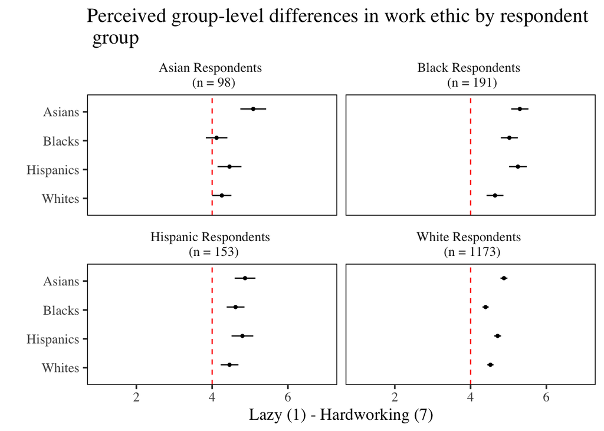

### Intelligence

Question wording: “A score of 1 means you think almost all people in that group are”intelligent" and a score of 7 means you think all people in that group are “unintelligent”. A score of 4 means you think the group is not towards one end or the other, and of course you may choose any number in between."

Responses are re-coded so that higher values indicate higher levels of perceived intelligence. The results, plotted below, are again very similar. Asian respondents show the highest levels of in-group favoritism. White respondents, on average, rated blacks and hispanics as less intelligence than whites and asians. All groups, on average, rated asians as the most intelligent.

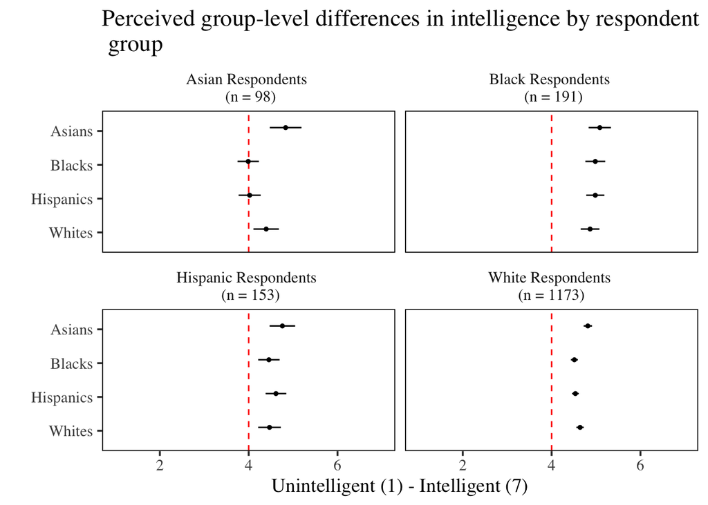

### Trustworthiness

Question wording: “A score of 1 means you think almost all people in that group are”untrustworthy" and a score of 7 means you think all people in that group are “trustworthy”. A score of 4 means you think the group is not towards one end or the other, and of course you may choose any number in between."

Again, asian respondents show the largest in group favoritism on this dimension. Black respondents view whites as the least trustworthy group, and white respondents view blacks as the least trustworthy of the groups.

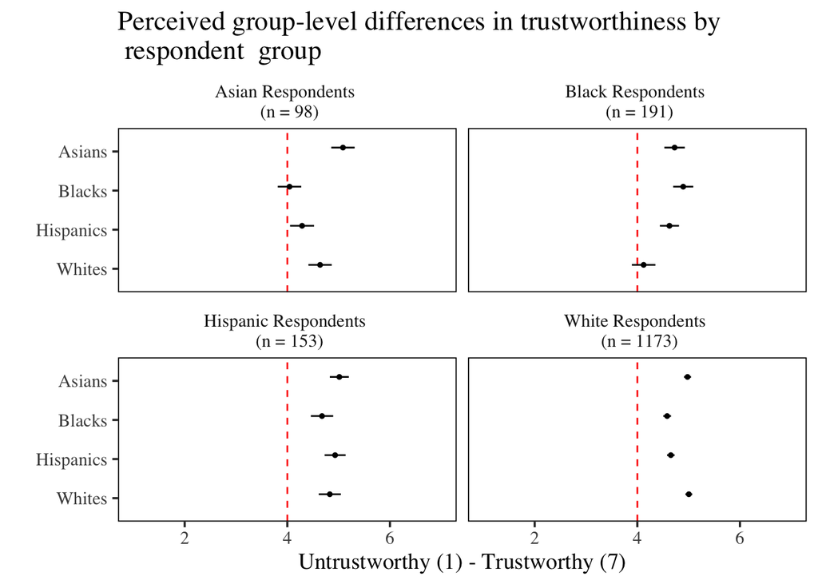

### Aggression

Question wording: “A score of 1 means you think almost all people in that group are”violent" and a score of 7 means you think all people in that group are “peaceful”. A score of 4 means you think the group is not towards one end or the other, and of course you may choose any number in between."

Asian respondents again show the highest levels of in-group favoritism on this measure. The gap between their evaluations of their own group and blacks is also the largest of all survey respondent groups. Black respondents view whites as the least trustworthy group, and white respondents view blacks as the least trustworthy group. All respondent groups view asians as the most trustworthy group.

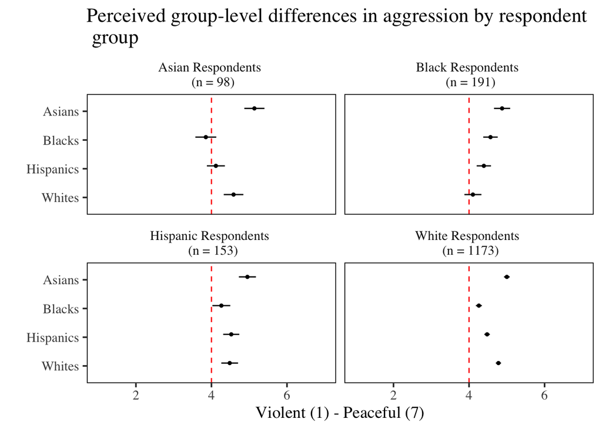

# Overt racism

Now I compute a measure of overt racism, focusing specifically on anti-black prejudice. First, I focus simply on perceived group differences between blacks and whites by subtracting each respondent’s “laziness” rating for blacks from the corresponding laziness rating for whites. For each trait, a positive score indicates the respondent ranked blacks as inferior to whites.

Next, for each respondent, I take the difference between their evaluation of blacks as a group, and their own group on each of the four stereotype dimensions explored above. Each respondent then receives a score that correspondens to their belief in their own group’s superiority over “blacks”. For example, for asian respondents, this is the extent to which they believe blacks as a group are inferior to asians with respect to work ethic, trustworthiness, etc.

### Work ethic

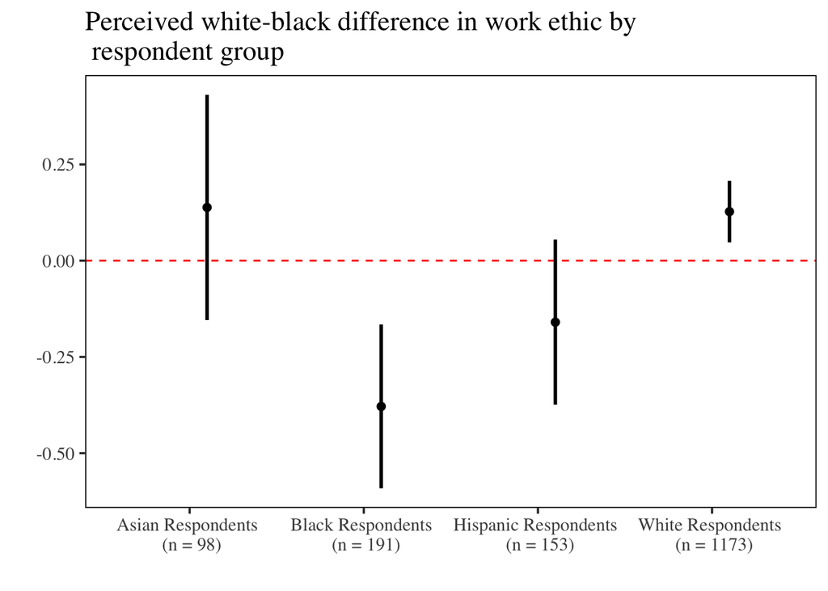

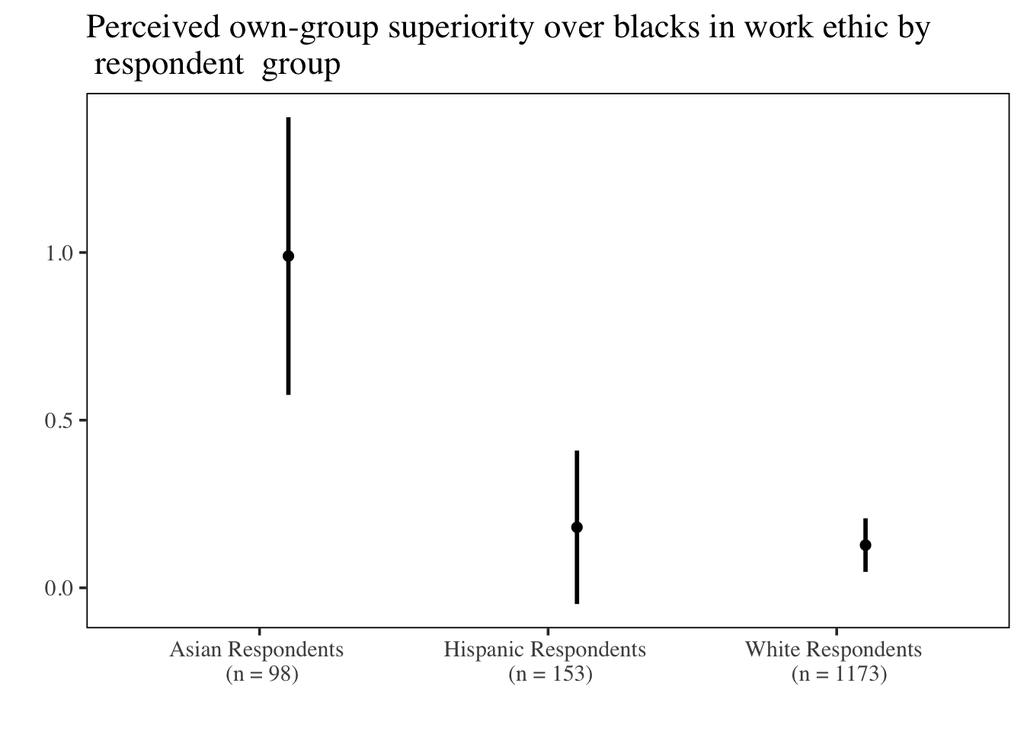

### Intelligence

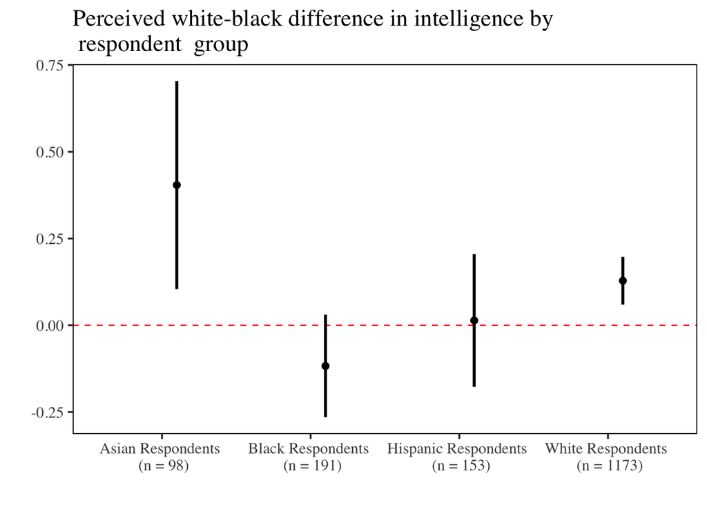

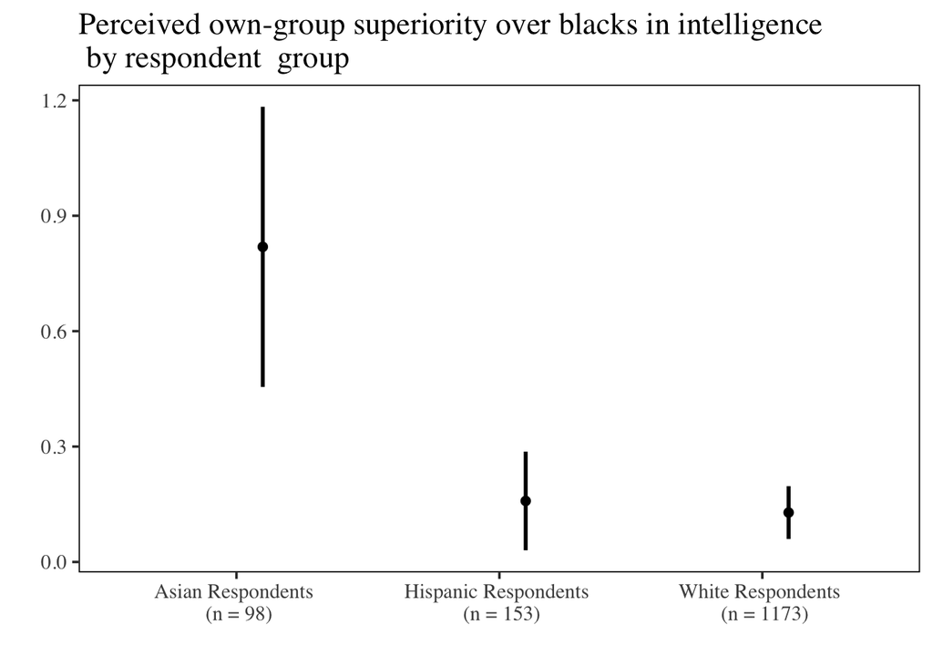

### Trustworthiness

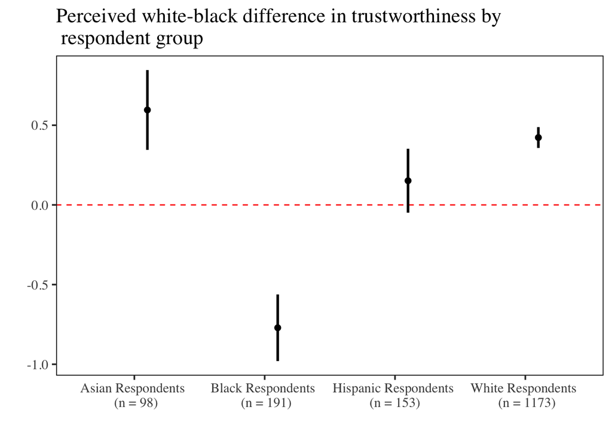

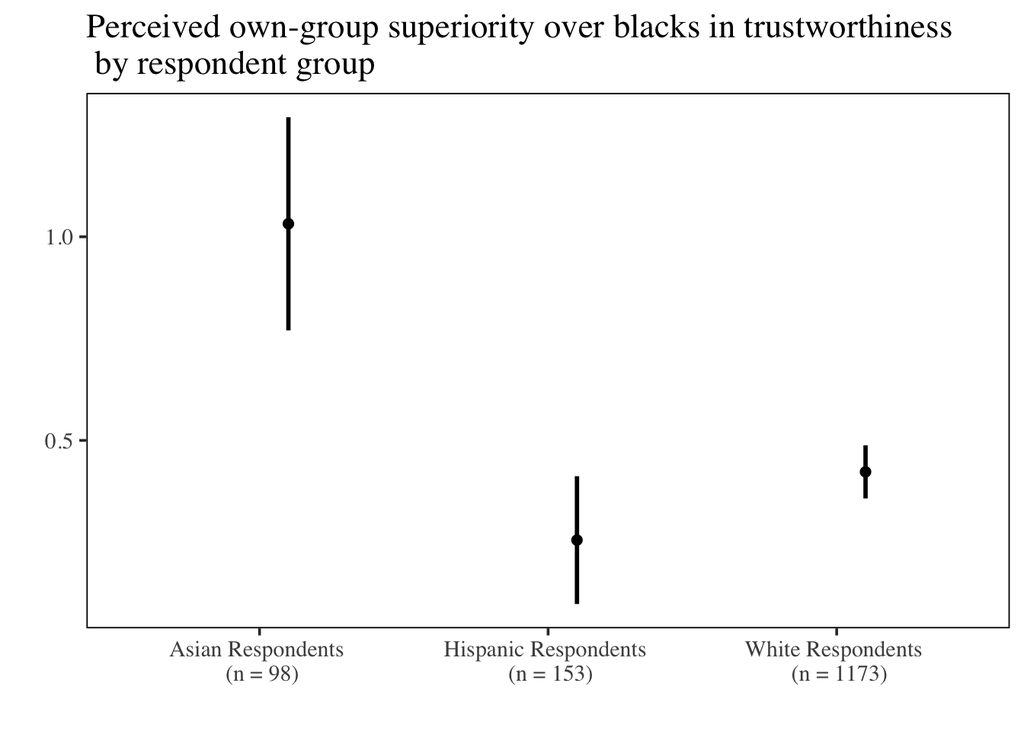

### Aggression

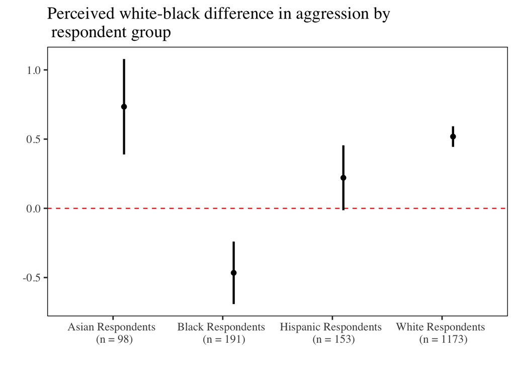

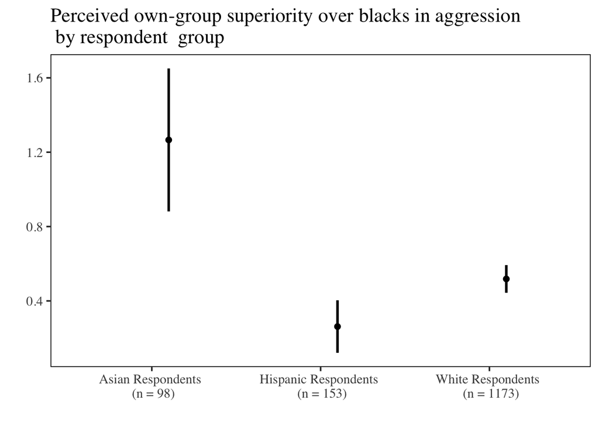

# Social status

Now let’s look at how people view social hierarchy via the ladder question. The plot below illustrates the variation in how survey respondents ranked each group (dark colors indicate more responses). The “Lower class” was, on average, rated the lowest and the “Upper class” was rated the highest. While there was a great deal of variation in where people ranked the various groups, almost everyone agreed that the Upper Class occupied the highest rung on the ladder.

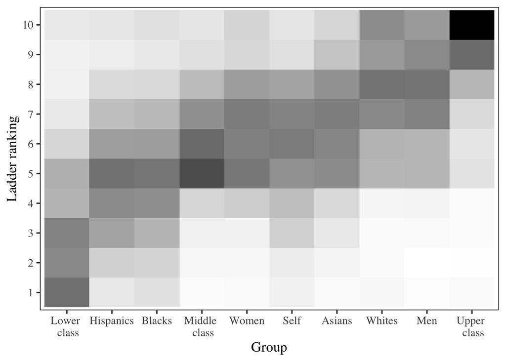

Plotting the raw data makes this overall variation more obvious:

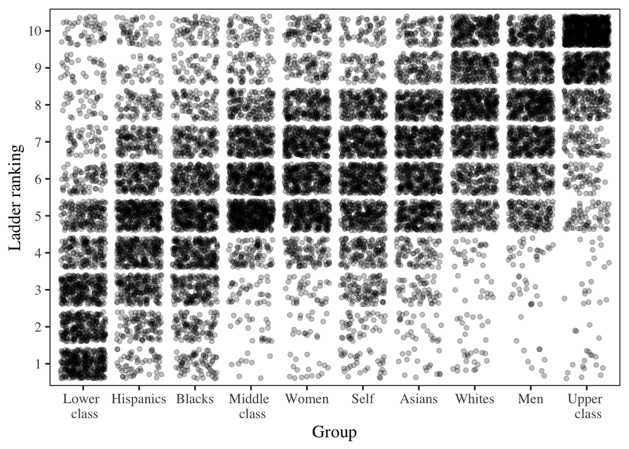

Finally, let’s look at the relationship between overt racism and where people place “blacks” versus “whites” on the ladder. I compute a summary measure of overt racism by adding up the perceived white-black differences across all four traits to create an “overt racism index”. I use this to explore the white - black difference in ladder ranking. The plot below shows the raw data with a linear smoother.

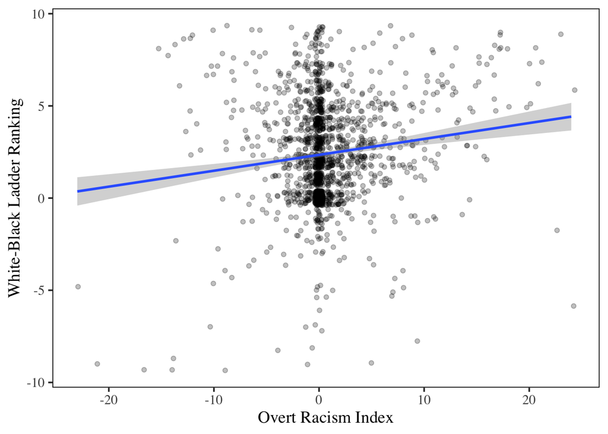

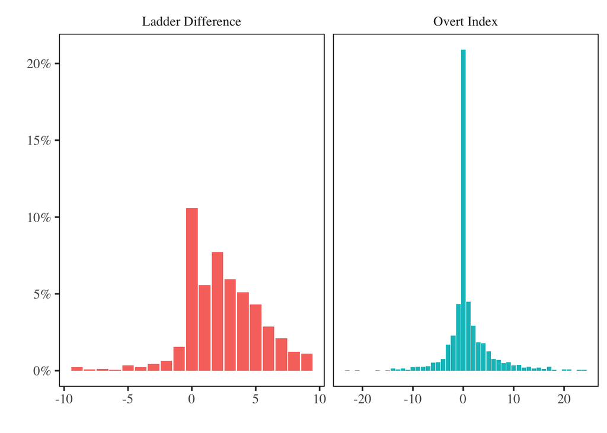

We can summarize the relationship with Bayes rule. Let $OR$ denote the probability of being an overt racist, and $LD$ denote the probability of rating whites above blacks on the status ladder.

$$\text{Pr}(OR\ | \ LD) = \frac{\text{Pr}(LD\ |\ OR)\cdot\text{Pr}(OR)}{\text{Pr}(LD)} \approx \frac{0.80\cdot0.32}{0.67} \approx 0.38$$